# Education and IRS

[figure not shown]

[figure not shown]

[figure not shown]

[figure not shown]

[figure not shown]

[figure not shown]

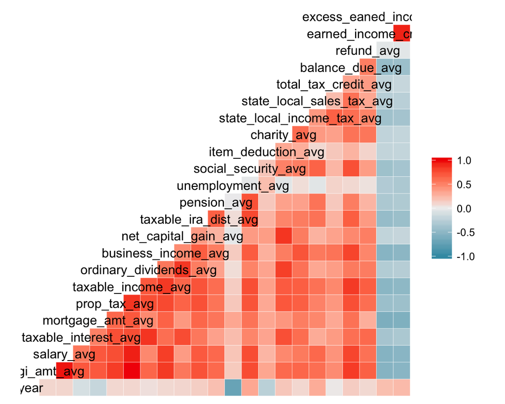

The data is sourced from [IRS](https://www.irs.gov/statistics/soi-tax-stats-individual-income-tax-statistics-zip-code-data-soi) for all Tennessee zip codes for Tax Years 2011, 2012, 2013, 2014, and 2015

All positive wealth markers co relate positively.

Excess income credit and earned income credit negatively co relate with positive wealth markers.

Average Unemployment compensation is worth taking an individual look at.

### Average Unemplyment Compensation Over the Years

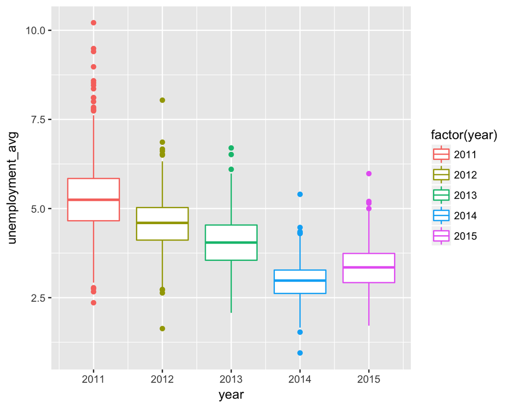

This is a good trend, and corelates well with unemployment rate reported for [TN](https://data.bls.gov/timeseries/LASST470000000000003)

### Correlation Matrix for Education Data: Data collected for the public school K-12 system for the year 2014 across the state of TN.

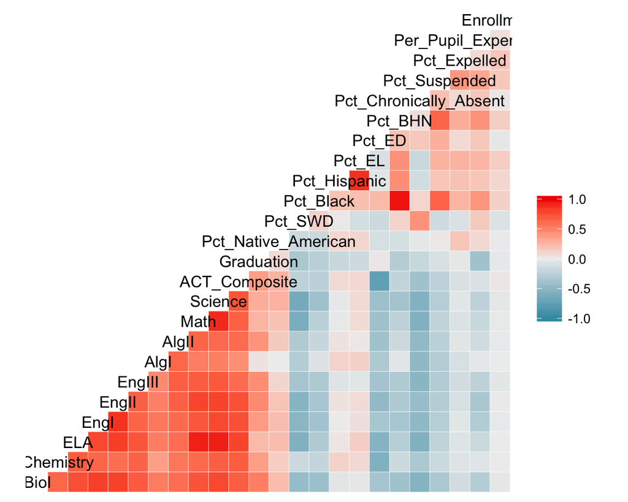

All performace markers co relate positively with each other such as differnt test scores and graduation rate.

Discipline and attendance (lack of!) markers positively corelate with each other and negatively with performance markers. This comes as no surprise at [absenteeism hinders learning.](https://www.theatlantic.com/education/archive/2015/09/skipping-school-hurting-younger-learners/403309/)

Per Pupil expense seems to co relate positively with discipline markers, are we throwing money at the problem or is there more to it?

### Per Pupil Expenditure and ACT Composite Performance

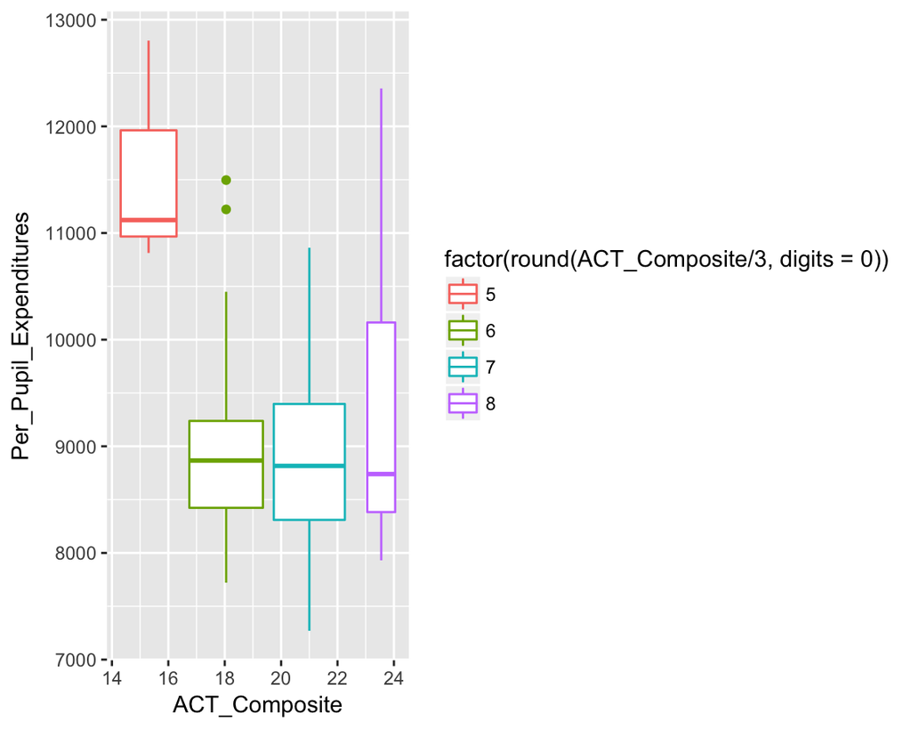

schools with low ACT scores are getting more funding, but so are schools that are performing high on ACT scores.

Reality as always is more complex than that.

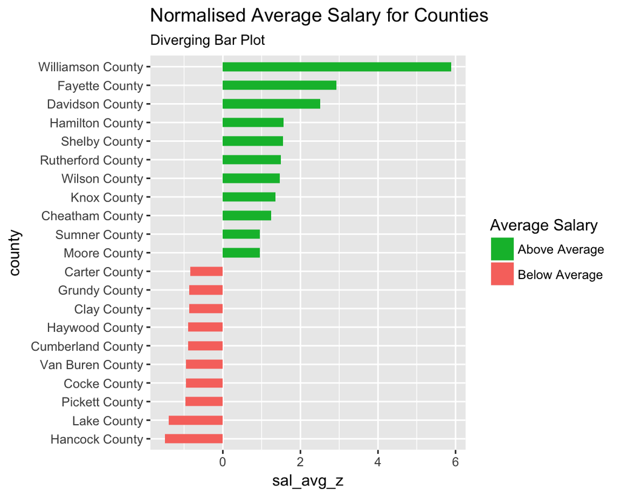

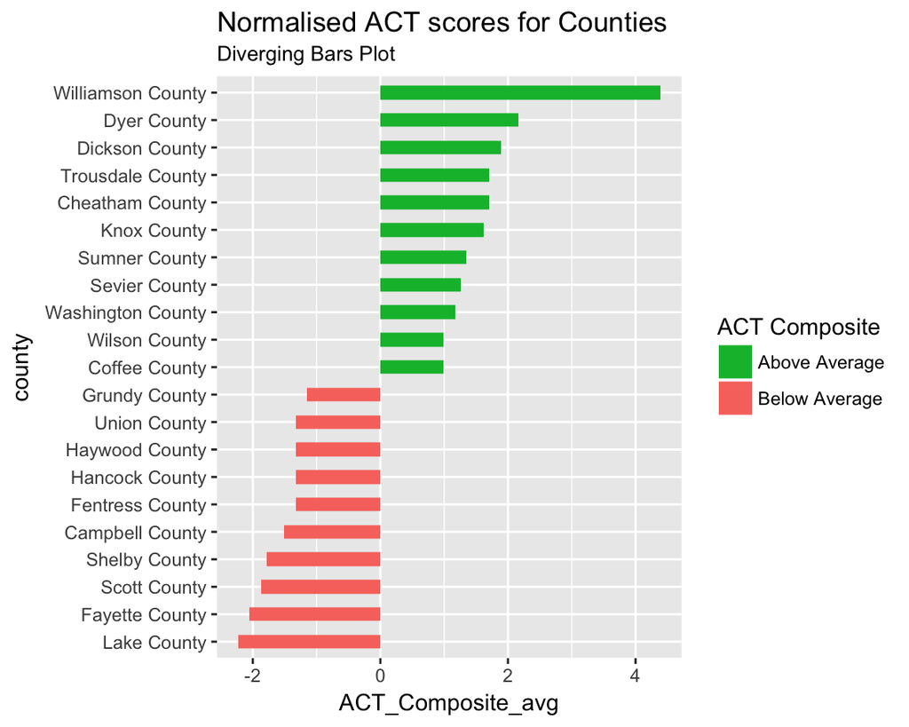

There are a hoard of articles and studies that tie socioeconomic status, [earning potential](https://ed100.org/lessons/poverty) of parents to student [performance outcomes](https://www.nashville.gov/Portals/0/SiteContent/SocialServices/docs/plann_coord/ChildPoverty120215.pdf).

The way these are done are generally at individual family levels or tightly knit homogenous communities. That kind of data at a similar granularity is not what we have and makes our studies and comparisons complicated and noisy.